# neuro-521-gilmore-2015-01-19

2016-01-20 07:11:13

## 2015-01-19 – Maps in the cortex

## Questions

1. What is the evidence for a topographic organization in sensory and motor processing?
2. Are maps fundamental to sensory processing or merely a byproduct of other factors?

## Readings

**Kaas, J. H. (1997). Topographic Maps are Fundamental to Sensory Processing. Brain Research Bulletin, 44(2), 107–112. http://doi.org/10.1016/S0361-9230(97)00094-4**

Weinberg, R. J. (1997). Are Topographic Maps Fundamental to Sensory Processing? Brain Research Bulletin, 44(2), 113–116. http://doi.org/10.1016/S0361-9230(97)00095-6

### Supplemental

Penfield, W., & Boldrey, E. (1937). Somatic Motor and Sensory Representation in the Cerebral Cortex of Man as Studied by Electrical Stimulation. Brain, 60(4), 389–443. http://doi.org/10.1093/brain/60.4.389

## Maps in the brain

- Retinotopy
- Somatotopy
- Tonotopy

## [Retinotopy](http://www.scholarpedia.org/article/Visual_map)

[figure not shown]

## Retinotopy

[figure not shown]

## Orientation maps

[figure not shown]

## Ocular dominance columns

[figure not shown]

## Retinotopy in human visual cortex

- [(Warnking et al. 2002)](http://doi.org/10.1006/nimg.2002.1304)
- Individual differences, size can vary by factor of 3 [(Dougherty et al. 2003)](http://doi.org/10.1167/3.10.1), may influence size perception [(Schwarzkopf, Song, and Rees 2011)](http://doi.org/10.1038/nn.2706), acuity thresholds (Duncan and Boynton 2003)

## Somatotopy

- Dermatomes
- S1
- Cerebellum

## Dermatomes

[figure not shown]

## Dermatomes and refererred pain

[figure not shown]

## [Primary somatosensory cortex (S1)](http://www.scholarpedia.org/article/S1_somatotopic_maps)

[figure not shown]

[(Penfield and Boldrey 1937)](http://doi.org/10.1093/brain/60.4.389)

## Cerebellar somatotopy [(Manni and Petrosini 2004)](http://doi.org/10.1038/nrn1347)

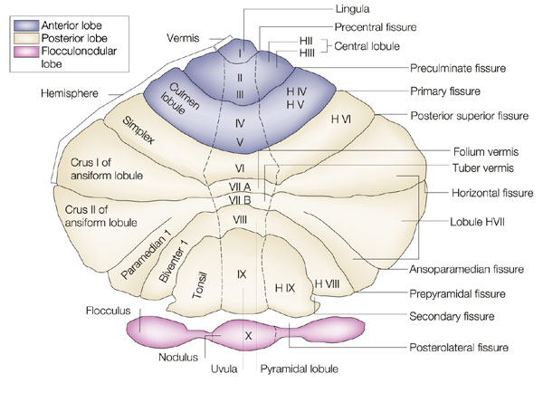

## Cerebellar somatotopy [(Manni and Petrosini 2004)](http://doi.org/10.1038/nrn1347)

[figure not shown]

## Cerebellar somatotopy [(Manni and Petrosini 2004)](http://doi.org/10.1038/nrn1347)

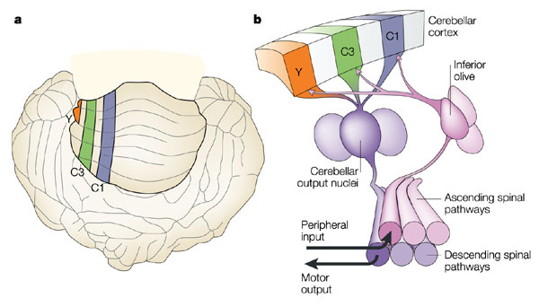

## Tonotopy

- Early fMRI evidence from humans (Wessinger et al. 1997)
- Strict tonotopy breaks down under high resolution in rat, [(Castro and Kandler 2010)](http://doi.org/10.1038/nn0310-271)
- Broad vs. narrow frequency tuning to natural sounds in human fMRI, [(Moerel, Martino, and Formisano 2012)](http://doi.org/10.1523/JNEUROSCI.1388-12.2012)

## Computational maps in the brain

- Example: computing interaural time differences [(Knudsen, Lac, and Esterly 1987)](http://doi.org/10.1146/annurev.ne.10.030187.000353)
- Maps in association cortex may have different organization [(Patel, Kaplan, and Snyder 2014)](http://doi.org/10.1016/j.tics.2014.03.008)

## (Kaas 1997) points

- Topographic maps of receptor surfaces occupy much of neo- cortex of all mammalian species. This suggests that they are important.
- To the extent that such maps emerge in development as a result of an interaction between relatively few factors, map features may be linked. Thus, all features of maps may not be adaptive or have useful functional consequences.

## (Kaas 1997) points

- Topographical maps effectively group neurons that most com- monly interact, thus decreasing requirements for long, slow, and metabolically costly connections. Such connections are also reduced by the topographic congruences of adjoining maps, and the grouping of maps that interact the most.

## (Kaas 1997) points

- Topographic maps are important components of many current theories of how visual information is processed. The maps seem especially well-suited for the construction of local neural circuits that make center-surround comparisons.
- An isomorphism seems to exist between many aspects of perception and imagery and the topographic features of maps.

## (Kaas 1997) points

- While lesions of topographic maps do not always disrupt perception in ways expected from the presumed functional roles of such maps, preserved functions may depend on other representations, or on the repair and recovery of damaged representations.

## (Weinberg 1997) worries

- How precise is the map?
- Where is the homunculus?
- Phenomenon or epiphenomenon?

## Other questions

- What is the "map" of internal actions or states [(Swanson 2007)](http://larrywswanson.com/?page_id=1523)?
- Are "motor" maps really somatotopic? (Graziano 2016)
- Animals compute quantities; how do maps/networks (Gallistel and King 2011)?

## References

Castro, Jason B., and Karl Kandler. 2010. “Changing Tune in Auditory Cortex.” *Nature Neuroscience* 13 (3): 271–73. doi:10.1038/nn0310-271.

Dougherty, R. F., V. M. Koch, A. A. Brewer, B. Fischer, J. Modersitzki, and B. A. Wandell. 2003. “Visual Field Representations and Locations of Visual Areas V1/2/3 in Human Visual Cortex.” *Journal of Vision* 3 (10): 1–1. doi:10.1167/3.10.1.

Duncan, Robert O., and Geoffrey M. Boynton. 2003. “Cortical Magnification Within Human Primary Visual Cortex Correlates with Acuity Thresholds.” *Neuron* 38 (4): 659–71. doi:10.1016/S0896-6273(03)00265-4.

Gallistel, C. R., and Adam Philip King. 2011. *Memory and the Computational Brain: Why Cognitive Science Will Transform Neuroscience*. John Wiley & Sons.

Graziano, Michael S. A. 2016. “Ethological Action Maps: A Paradigm Shift for the Motor Cortex.” *Trends in Cognitive Sciences* 0 (0). Accessed January 19. doi:10.1016/j.tics.2015.10.008.

Kaas, Jon H. 1997. “Topographic Maps Are Fundamental to Sensory Processing.” *Brain Research Bulletin* 44 (2): 107–12. doi:10.1016/S0361-9230(97)00094-4.

Knudsen, Eric I, S du Lac, and Steven D Esterly. 1987. “Computational Maps in the Brain.” *Annual Review of Neuroscience* 10 (1). Annual Reviews 4139 El Camino Way, PO Box 10139, Palo Alto, CA 94303-0139, USA: 41–65. doi:10.1146/annurev.ne.10.030187.000353.

Manni, Ermanno, and Laura Petrosini. 2004. “A Century of Cerebellar Somatotopy: A Debated Representation.” *Nature Reviews Neuroscience* 5 (3): 241–49. doi:10.1038/nrn1347.

Moerel, Michelle, Federico De Martino, and Elia Formisano. 2012. “Processing of Natural Sounds in Human Auditory Cortex: Tonotopy, Spectral Tuning, and Relation to Voice Sensitivity.” *The Journal of Neuroscience* 32 (41): 14205–16. doi:10.1523/JNEUROSCI.1388-12.2012.

Patel, Gaurav H., David M. Kaplan, and Lawrence H. Snyder. 2014. “Topographic Organization in the Brain: Searching for General Principles.” *Trends in Cognitive Sciences* 18 (7): 351–63. doi:10.1016/j.tics.2014.03.008.

Penfield, Wilder, and Edwin Boldrey. 1937. “Somatic Motor and Sensory Representation in the Cerebral Cortex of Man as Studied by Electrical Stimulation.” *Brain* 60 (4): 389–443. doi:10.1093/brain/60.4.389.

Schwarzkopf, D. Samuel, Chen Song, and Geraint Rees. 2011. “The Surface Area of Human V1 Predicts the Subjective Experience of Object Size.” *Nature Neuroscience* 14 (1): 28–30. doi:10.1038/nn.2706.

Swanson, Larry W. 2007. “Quest for the Basic Plan of Nervous System Circuitry.” *Brain Research Reviews* 55 (2): 356–72. doi:10.1016/j.brainresrev.2006.12.006.

Warnking, J., M. Dojat, A. Guérin-Dugué, C. Delon-Martin, S. Olympieff, N. Richard, A. Chéhikian, and C. Segebarth. 2002. “fMRI Retinotopic Mapping—Step by Step.” *NeuroImage* 17 (4): 1665–83. doi:10.1006/nimg.2002.1304.

Weinberg, Richard J. 1997. “Are Topographic Maps Fundamental to Sensory Processing?” *Brain Research Bulletin* 44 (2): 113–16. doi:10.1016/S0361-9230(97)00095-6.

Wessinger, C. Mark, Michael H. Buonocore, Clif L. Kussmaul, and George R. Mangun. 1997. “Tonotopy in Human Auditory Cortex Examined with Functional Magnetic Resonance Imaging.” *Human Brain Mapping* 5 (1): 18–25. doi:10.1002/(SICI)1097-0193(1997)5:1<18::AID-HBM3>3.0.CO;2-Q.